# International Soccer Anaylsis

Abel Del Pino

May 17th

# 1 Introduction

## 1.1 Motivaton

In regards to the upcoming 2018 Fifa World Cup that is happening in Russia this Summer, I decided that it would be interesting to analyze data on international matches in order to learn about possible trends that may or may not exist. As well, I wanted to see if it would be possible to make some sort of prediction on the favorite to win the this year’s World Cup.

We will be able to gain insight using regression analysis to see trends that we might have not expected or not see trends were we might have once expected there to be a trend in Soccer in a manner thats designed to not be biased as people can be when discussing sports such as Soccer.

## 1.2 Getting Started

The dataset we wil use for this analysis was taken from https://www.kaggle.com/martj42/international-football-results-from-1872-to-2017.

After downloading the .csv file and placing it in the desired folder. We will begin by loading in our data and looking at the first few lines of the data using head().

```r
soccer <- read.csv('./data/results.csv')
head(soccer)
```

```
##         date home_team away_team home_score away_score tournament    city
## 1 1872-11-30  Scotland   England          0          0   Friendly Glasgow
## 2 1873-03-08   England  Scotland          4          2   Friendly  London
## 3 1874-03-07  Scotland   England          2          1   Friendly Glasgow
## 4 1875-03-06   England  Scotland          2          2   Friendly  London
## 5 1876-03-04  Scotland   England          3          0   Friendly Glasgow
## 6 1876-03-25  Scotland     Wales          4          0   Friendly Glasgow
##    country neutral
## 1 Scotland   FALSE
## 2  England   FALSE
## 3 Scotland   FALSE
## 4  England   FALSE
## 5 Scotland   FALSE
## 6 Scotland   FALSE
```

We will also use a dataset (from https://www.kaggle.com/folaraz/world-countries-and-continents-details) that connects countries to their continents to make it easy for us to do future analysis related to continents. We can just select() the name and continent attributes of the data. We will use the `dplyr` package to allow us to use pipelines with `%>%` which will allow us to do operations with the data in a more elegant way than normal. We will also update the data to no longer be abbreviations of the Continents by creating a table with `tribble` and inner joining it with the continents table and selecting these new updated values.

Here as a result of the `ifelse` that is being used to update the values of the continents because North America is seen as an NA value, we must use the number mappings of each continent.

```r
library(dplyr)
continents <- read.csv('./data/countriescontinents.csv')
continents <- continents %>%
  mutate(Continent = ifelse(is.na(Continent), "8", Continent)) %>%
  select(name, Continent)
map <- tribble(
  ~Continent, ~new_Continent,
  "2",      "Africa",
  "3",      "Antartica",
  "4",      "Asia",
  "5",      "Europe",
  "8",      "North America",
  "6",      "Oceania",
  "7",      "South America"
)
continents <- continents %>%
  inner_join(map, by="Continent") %>%
  select(name, continent = new_Continent)
head(continents)
```

```
##             name continent
## 1    Afghanistan      Asia
## 2        Albania    Europe
## 3        Algeria    Africa
## 4 American Samoa   Oceania
## 5        Andorra    Europe
## 6         Angola    Africa
```

In order to connect the two data sets we will use the an inner_join again which will connect the two tables on the countries combining the two tables where “home_team” = “name” and “away_team” = “name” so that we know what continent the home team and away team come from. We also use a select in order to rearrange the columns of the table in a way that allows us to see these values.

```r
soccer <- soccer %>%
  inner_join(continents, by=c("home_team" = "name")) %>%
  inner_join(continents, by=c("away_team" = "name")) %>%
  select(date, home_team, home_continent = continent.x, away_team, away_continent = continent.y, home_score, away_score, tournament,
          city, country, neutral)
head(soccer)
```

```
##         date home_team home_continent away_team away_continent home_score
## 1 1872-11-30  Scotland         Europe   England         Europe          0
## 2 1873-03-08   England         Europe  Scotland         Europe          4
## 3 1874-03-07  Scotland         Europe   England         Europe          2
## 4 1875-03-06   England         Europe  Scotland         Europe          2
## 5 1876-03-04  Scotland         Europe   England         Europe          3
## 6 1877-03-03   England         Europe  Scotland         Europe          1
##   away_score tournament    city  country neutral
## 1          0   Friendly Glasgow Scotland   FALSE
## 2          2   Friendly  London  England   FALSE
## 3          1   Friendly Glasgow Scotland   FALSE
## 4          2   Friendly  London  England   FALSE
## 5          0   Friendly Glasgow Scotland   FALSE
## 6          3   Friendly  London  England   FALSE
```

# 2 Exploratory Data Analysis

Now that we have all the data that we want setup we can now start performing analysis on it. From this information we will ask questions about trends and see if there is truly some patterns in the soccer data that we have. We will visualize parts of the data and see if we notice anything.

## 2.1 Continents in the World Cup

The first question we will want to answer is, “What continents have been the most successful at the World Cup?”. We will be able to viusalize the win rate that each continent has in the world cup and see how there win rate has changed over time.

### 2.1.1 Setup

We will begin by selected only the data from the World Cup. We will do this by using the `filter` function to select only those games where the tournament the game was being played at was the FIFA World Cup. We will also change the date attribute to only include the year part of the date by using function `substr` that will allow us to only take the first 4 characters from the date.

```r
world_cup <- soccer %>%
  filter(tournament == "FIFA World Cup") %>%
  mutate(date = substr(date, 1, 4)) # Only the year is relevant from the date
head(world_cup)
```

```
##   date home_team home_continent away_team away_continent home_score
## 1 1930   Belgium         Europe       USA  North America          0
## 2 1930    France         Europe    Mexico  North America          4
## 3 1930      Peru  South America   Romania         Europe          1
## 4 1930 Argentina  South America    France         Europe          1
## 5 1930     Chile  South America    Mexico  North America          3
## 6 1930  Paraguay  South America       USA  North America          0
##   away_score     tournament       city country neutral
## 1          3 FIFA World Cup Montevideo Uruguay    TRUE
## 2          1 FIFA World Cup Montevideo Uruguay    TRUE
## 3          3 FIFA World Cup Montevideo Uruguay    TRUE
## 4          0 FIFA World Cup Montevideo Uruguay    TRUE
## 5          0 FIFA World Cup Montevideo Uruguay    TRUE
## 6          3 FIFA World Cup Montevideo Uruguay    TRUE
```

Next we will determine which continent won and which lost in each match by creating two new attributes “won” and “lost”. We will use an `ifelse` that will determine which value to put in the new column based on if the home team or away team scored more. Based on this, the corresponding continent of the winning team will be put in the won column and the corresponding continent of the losing team will be placed in the lost column.

We will also take care of the case where two teams of the same continent place each other by counting it solely as a win and not a lost because this will reflect the continent’s dominance in that world cup.

```r
world_cup <- world_cup %>%
  mutate(won = ifelse(home_score >= away_score, home_continent, away_continent)) %>%
  mutate(lost = ifelse(home_score >= away_score, away_continent, home_continent)) %>%
  mutate(lost = ifelse(won == lost, NA, lost))
head(world_cup)
```

```
##   date home_team home_continent away_team away_continent home_score
## 1 1930   Belgium         Europe       USA  North America          0
## 2 1930    France         Europe    Mexico  North America          4
## 3 1930      Peru  South America   Romania         Europe          1
## 4 1930 Argentina  South America    France         Europe          1
## 5 1930     Chile  South America    Mexico  North America          3
## 6 1930  Paraguay  South America       USA  North America          0
##   away_score     tournament       city country neutral           won
## 1          3 FIFA World Cup Montevideo Uruguay    TRUE North America
## 2          1 FIFA World Cup Montevideo Uruguay    TRUE        Europe
## 3          3 FIFA World Cup Montevideo Uruguay    TRUE        Europe
## 4          0 FIFA World Cup Montevideo Uruguay    TRUE South America
## 5          0 FIFA World Cup Montevideo Uruguay    TRUE South America
## 6          3 FIFA World Cup Montevideo Uruguay    TRUE North America
##            lost
## 1        Europe
## 2 North America
## 3 South America
## 4        Europe
## 5 North America
## 6 South America
```

Now we can create two separate tables, one for all the wins and one for all the loses. We can then use `group_by` and `summarize(n())` on each table to determine how many times each continent won and how many times they lost. We will also drop rows with NA by using `drop_na` from the `tidyr` package.

```r
library(tidyr)
world_cup_wins <- world_cup %>%
  select(date, won) %>%
  group_by(date, won) %>%
  summarize(n())
world_cup_loses <- world_cup %>%
  select(date, lost) %>%
  drop_na() %>%
  group_by(date, lost) %>%
  summarize(n())
head(world_cup_wins)
```

```
## # A tibble: 6 x 3
## # Groups:   date [3]
##   date  won           `n()`
##   <chr> <chr>         <int>
## 1 1930  Europe            2
## 2 1930  North America     2
## 3 1930  South America    11
## 4 1934  Europe           13
## 5 1938  Europe           11
## 6 1938  North America     2
```

We can then use an `inner_join` to combine these results and a `mutate` to determine a continent’s winrate(Games Won / Games Played) for a given World Cup and creating the corresponding new column.

```r
world_cup_results <- world_cup_wins %>%
  inner_join(world_cup_loses, by=c("date" = "date", "won" = "lost")) %>%
  select(date, continent = won, won = "n().x", lost = "n().y") %>% # fixing attribute names
  mutate(winrate = won / (won + lost))
world_cup_results
```

```
## # A tibble: 73 x 5
## # Groups:   date [19]
##    date  continent       won  lost winrate
##    <chr> <chr>         <int> <int>   <dbl>
##  1 1930  Europe            2     5   0.286
##  2 1930  North America     2     4   0.333
##  3 1930  South America    11     2   0.846
##  4 1938  Europe           11     4   0.733
##  5 1938  North America     2     1   0.667
##  6 1938  South America     2     1   0.667
##  7 1950  Europe            9     6   0.600
##  8 1950  North America     1     4   0.200
##  9 1950  South America     9     4   0.692
## 10 1954  Europe           16     2   0.889
## # ... with 63 more rows
```

### 2.1.2 Visualing the Data

We now have data on how well each Continent has done each year the World cup has been held.

To visualize this data we will use a package called `ggplot2` which will plot each Continents winrate for each World Cup with year on the x-axis and winrate on the y-axis.

Here we are using `ggplot()` to map which attributes we want on the x-axis and which we want on the y-axis. We then use `+` to add new features to our plot, such as `goem_smooth` which will plot a line for each of the continents and color code each continent, `ylim` which allows us to designate the scale of the y-axis, and the last 3 commands which allow us to label the graph we have just created.

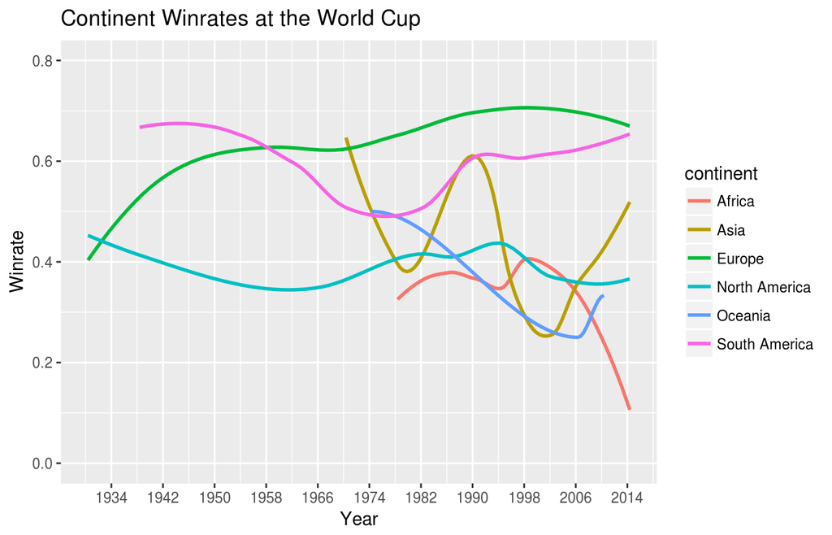

```r
library(ggplot2)
world_cup_results %>%
  ggplot(aes(x=as.Date(date, "%Y"), y = winrate)) +
    geom_smooth(se = FALSE, aes(group = continent, color = continent)) +
    ylim(0, 0.8) +
    xlab("Year") +
    ylab("Winrate") +
    ggtitle("Continent Winrates at the World Cup") +
    scale_x_date(date_breaks = '8 years', date_labels = '%Y')
```

### 2.1.3 Analyis

We can also see that North America has had a very consistent winrate throughout the history of the World Cup. The winrate has stayed within about 5% of 40% since the beginning of the World Cup for North America.

We can also see that the 3 other continents(Africa, Asia, Oceania), all have had historically the worst performances at the World Cup. They also happen to be the 3 continents that were each last to participate in the World Cup.

In the bigger picture we can predict that if a team is going to win the World Cup, they are probably going to come from either Europe or South America.

## 2.2 Home Field Advantage

Next we can ask a different question that will entail all the data we have. “Does playing in your home continent give you a better chance at winning a game?” To answer this we can use all the available data we have on the international matches.

### 2.2.1 Setup

We can take the soccer table that we created before with the continents of each team to determine which team has home field advantage if any. Let us see what we have right now.

```r
head(soccer)
```

```
##         date home_team home_continent away_team away_continent home_score
## 1 1872-11-30  Scotland         Europe   England         Europe          0
## 2 1873-03-08   England         Europe  Scotland         Europe          4
## 3 1874-03-07  Scotland         Europe   England         Europe          2
## 4 1875-03-06   England         Europe  Scotland         Europe          2
## 5 1876-03-04  Scotland         Europe   England         Europe          3
## 6 1877-03-03   England         Europe  Scotland         Europe          1
##   away_score tournament    city  country neutral
## 1          0   Friendly Glasgow Scotland   FALSE
## 2          2   Friendly  London  England   FALSE
## 3          1   Friendly Glasgow Scotland   FALSE
## 4          2   Friendly  London  England   FALSE
## 5          0   Friendly Glasgow Scotland   FALSE
## 6          3   Friendly  London  England   FALSE
```

We need to know what continent each game is being played at. We can also not include games where both teams playing where in their home continent as well as where no team was in their home continent because including these games would mess up the results and skew the data. We can use the same `inner_join` we used before to add these continents for the place the game is being played at. We can also use `select` so that we only use the attributes that are relevant to the question.

```r
home_soccer <- soccer %>%
  inner_join(continents, by=c("country" = "name")) %>%
  select(date, home_team, home_continent, away_team, away_continent, home_score, away_score, continent) %>%
  filter(home_continent != away_continent) %>%
  filter(home_continent == continent || away_continent == continent)
head(home_soccer)
```

```
##         date home_team home_continent away_team away_continent home_score
## 1 1888-09-19  Scotland         Europe    Canada  North America          4
## 2 1916-08-20    Sweden         Europe       USA  North America          2
## 3 1916-09-03    Norway         Europe       USA  North America          1
## 4 1921-07-09    Canada  North America  Scotland         Europe          0
## 5 1923-10-26    Turkey           Asia   Romania         Europe          2
## 6 1924-05-27     Egypt         Africa Lithuania         Europe         10
##   away_score     continent
## 1          0        Europe
## 2          3        Europe
## 3          1        Europe
## 4          1 North America
## 5          2          Asia
## 6          0        Europe
```

Next we need to determine if the team who was at home won the game or not. We will do this by creating a new attribute with `mutate` and `ifelse`.

```r
home_soccer <- home_soccer %>%
  mutate(home_won = ifelse(home_score > away_score,
                           ifelse(home_continent == continent, TRUE, FALSE), FALSE))
head(home_soccer)
```

```
##         date home_team home_continent away_team away_continent home_score
## 1 1888-09-19  Scotland         Europe    Canada  North America          4
## 2 1916-08-20    Sweden         Europe       USA  North America          2
## 3 1916-09-03    Norway         Europe       USA  North America          1
## 4 1921-07-09    Canada  North America  Scotland         Europe          0
## 5 1923-10-26    Turkey           Asia   Romania         Europe          2
## 6 1924-05-27     Egypt         Africa Lithuania         Europe         10
##   away_score     continent home_won
## 1          0        Europe     TRUE
## 2          3        Europe    FALSE
## 3          1        Europe    FALSE
## 4          1 North America    FALSE
## 5          2          Asia    FALSE
## 6          0        Europe    FALSE
```

### 2.2.2 Viusalization

Next we can see how each continent prefers when playing at home by comparing winrates in the same way we did before for the previous question (we will also keep the previous data for a different use later). We can use `group_by` again to group together the results of `home_won` for each continent ignoring date and some of the other attributes we do not need anymore.

```r
home_graph <- home_soccer %>%
  select(home_continent, away_continent, continent, home_won) %>%
  group_by(home_continent, home_won) %>%
  summarize(n())
head(home_graph)
```

```
## # A tibble: 6 x 3
## # Groups:   home_continent [3]
##   home_continent home_won `n()`
##   <chr>          <lgl>    <int>
## 1 Africa         F          377
## 2 Africa         T          139
## 3 Asia           F         1180
## 4 Asia           T          585
## 5 Europe         F          856
## 6 Europe         T          899
```

Here we are going to split the data again into 2. One for the wins and one for the loses and join them together. We will also determine the winrate for each continent at home.

```r
home_graph_win <- home_graph %>%
  filter(home_won == TRUE)
home_graph_lose <- home_graph %>%
  filter(home_won == FALSE)
home_graph <- home_graph_win %>%
  inner_join(home_graph_lose, by="home_continent") %>%
  select(home_continent, home_won = "home_won.x", num_won = "n().x", home_lost = "home_won.y", num_lose = "n().y") %>%
  mutate(winrate_home = num_won / (num_won + num_lose))
home_graph
```

```
## # A tibble: 6 x 6
## # Groups:   home_continent [6]
##   home_continent home_won num_won home_lost num_lose winrate_home
##   <chr>          <lgl>      <int> <lgl>        <int>        <dbl>
## 1 Africa         T            139 F              377        0.269
## 2 Asia           T            585 F             1180        0.331
## 3 Europe         T            899 F              856        0.512
## 4 North America  T            322 F              637        0.336
## 5 Oceania        T            105 F              190        0.356
## 6 South America  T            386 F              521        0.426
```

We will graph this results using a bar graph using `geom_bar`, mapping the corresponding values and labeling.

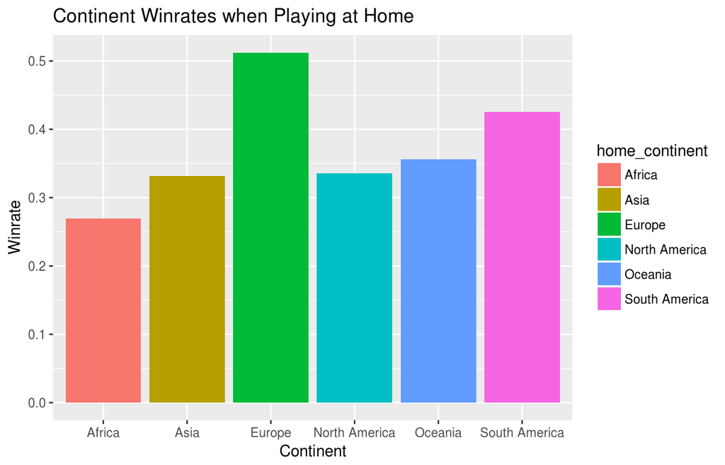

```r
home_graph %>%
  ggplot(mapping=aes(x=home_continent, y=winrate_home, fill=home_continent)) +
    geom_bar(stat="identity") +
    xlab("Continent") +
    ylab("Winrate") +
    ggtitle("Continent Winrates when Playing at Home")
```

### 2.2.3 Visualization for “Away Field Advantage”

We can also easily make some small modifications to our code to be able to see which team will have the advantage. All I change is changing the ifelse and changing all the places where home is the name of a variable to away.

```r
away_soccer <- home_soccer %>%
  mutate(away_won = ifelse(away_score > home_score,
                           ifelse(away_continent != continent, TRUE, FALSE), FALSE))
away_graph <- away_soccer %>%
  select(home_continent, away_continent, continent, away_won) %>%
  group_by(away_continent, away_won) %>%
  summarize(n())

away_graph_win <- away_graph %>%
  filter(away_won == TRUE)
away_graph_lose <- away_graph %>%
  filter(away_won == FALSE)
away_graph <- away_graph_win %>%
  inner_join(away_graph_lose, by="away_continent") %>%
  select(away_continent, away_won = "away_won.x", num_won = "n().x", home_lost = "away_won.y", num_lose = "n().y") %>%
  mutate(winrate_away = num_won / (num_won + num_lose))
head(away_graph)
```

```
## # A tibble: 6 x 6
## # Groups:   away_continent [6]
##   away_continent away_won num_won home_lost num_lose winrate_away
##   <chr>          <lgl>      <int> <lgl>        <int>        <dbl>
## 1 Africa         T            171 F              636        0.212
## 2 Asia           T            227 F             1030        0.181
## 3 Europe         T            673 F             1215        0.356
## 4 North America  T            150 F              614        0.196
## 5 Oceania        T             76 F              228        0.250
## 6 South America  T            423 F              754        0.359
```

Here we will graph in exactly the same way as done previously for the home winrates.

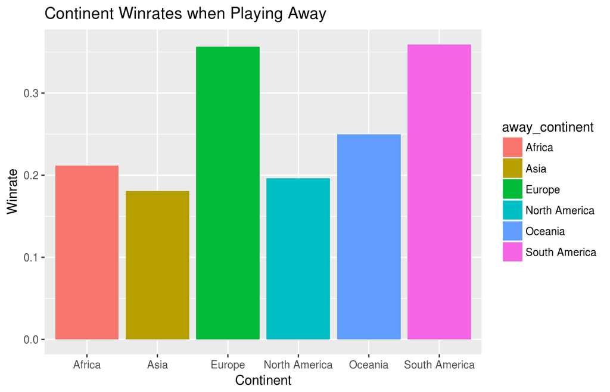

```r
away_graph %>%
  ggplot(mapping=aes(x=away_continent, y=winrate_away, fill=away_continent)) +
    geom_bar(stat="identity") +
    xlab("Continent") +
    ylab("Winrate") +
    ggtitle("Continent Winrates when Playing Away")
```

### 2.2.4 Analysis

For this upcoming World Cup no continent can really considered home because in Russia, Europe does not really count as playing at home. So european teams are effectively playing away. So considering the previous analysis of the graphs, South America seems to be favored from this analysis.

# 3 Logistic Regression

## 3.1 Introduction

We can use logisitic regression for a very simple example to determine how much score matters to winning the game. To do this we do not need that much setup. We can just use the home_soccer data and sample just using the home teams score and if they won or not. We will use the `broom` package for this.

## 3.2 Model

Here we are using the `broom` package to figure to test out the null hypothesis that there is no relationship between how much a team scores and if they win or not. You can read more about using the `glm` here https://www.statmethods.net/advstats/glm.html. But, it is very self explanatory. Home_score is our predictor and home_won is what we want to predict.

```r
library(broom)

score_model <- glm(home_won ~ home_score, data = home_soccer, family=binomial)
score_model %>%
  tidy() %>%
  knitr::kable(digits=4)
```

| term | estimate | std.error | statistic | p.value |
| --- | --- | --- | --- | --- |
| (Intercept) | -2.3124 | 0.0596 | -38.7706 | 0 |
| home_score | 1.2065 | 0.0331 | 36.5030 | 0 |

## 3.3 Analysis

To analyze this, we can evaluate the p-value and see that it is 0 for both the intercept and predictor. This means we can reject the null hypothesis that there is no relationship between the score and if they win or not, which means there is a relationship between the score and winning. Which is obviously not suprising and is expected.

# 4 Conclusion

Taking all the analysis we did into account, we can make some kind of prediction to see who could possibly win the 2018 Russia World Cup. Based on the first analysis we can see that it is very likely that the winner will come from Europe or South America. Then based on the second analysis, we can predict that a team from South America will win. So the final prediction from this full analysis is that the winner will come from South America.

It would be very hard to predict which specific country would win the World Cup, so for our purposes narrowing down a prediction to a Continent will suffice.

# 5 Further Reads

- Soccer Dataset - https://www.kaggle.com/martj42/international-football-results-from-1872-to-2017
- Continents Dataset - https://www.kaggle.com/folaraz/world-countries-and-continents-details
- Dplyr - http://stat545.com/bit001_dplyr-cheatsheet.html
- GGPlot2 - http://www.sthda.com/english/wiki/ggplot2-axis-scales-and-transformations
- Strings and Dates - https://stats.idre.ucla.edu/r/faq/how-can-i-format-a-string-containing-a-date-into-r-date-object/
- glm - https://www.statmethods.net/advstats/glm.html